# Data Extraction

Kehinde Fagbamigbe

2023-01-21

```r
rm(list = ls())
library(dplyr)
library(tidyverse)
path <- "/Users/alhajidot/Documents/BGSU/Project/UG_data/"

# Find all the files in the directory that match the pattern "[0-9][0-9][0-9][0-9].csv" e.g 1994.csv , 1995.csv e.t.c
files <- list.files(path, pattern = "[0-9][0-9][0-9][0-9].csv")

# Determine the number of files that match the pattern
num_files <- length(files)

# Print the result
print(num_files)
```

```
## [1] 14
```

### Using files to create start and end

```r
files <- as.list(files)
files
```

```
## [[1]]
## [1] "1994.csv"
##
## [[2]]
## [1] "1996.csv"
##
## [[3]]
## [1] "1998.csv"
##
## [[4]]
## [1] "2000.csv"
##
## [[5]]
## [1] "2002.csv"
##
## [[6]]
## [1] "2004.csv"
##
## [[7]]
## [1] "2006.csv"
##
## [[8]]
## [1] "2008.csv"
##
## [[9]]
## [1] "2010.csv"
##
## [[10]]
## [1] "2012.csv"
##
## [[11]]
## [1] "2014.csv"
##
## [[12]]
## [1] "2016.csv"
##
## [[13]]
## [1] "2018.csv"
##
## [[14]]
## [1] "2020.csv"
```

```r
start <- files[[1]]
start <- as.numeric(substr(start, 1, 4))
start
```

```
## [1] 1994
```

```r
end <- files[[length(files)]]
end <- as.numeric(substr(end, 1, 4))
end
```

```
## [1] 2020
```

### Race Acronyms and meanings

- EFAIAN –> American Indian or Alaska Native
- EFBKAA –> Black or African American
- EFHISP –> Hispanic
- EFWHIT –> White
- EFUNKN –> Race/ethnicity unknown
- EFNRAL –> Nonresident alien
- EFASIAM + EFNHPIM DVEFAIM / EFNHPI –> Native Hawaiian or Other Pacific Islander

## Courses

- 4 Architecture and Related Programs
- 13 Education
- 14 Engineering
- 22.0101 Law
- 26 Biological Sciences/Life Sciences
- 27 Mathematics
- 40 Physical Sciences
- 51 Medical
- 52 Business Management and Administrative Services

### varname varTitle

- CIPCODE CIP Code for major field of study
- EFAIANM American Indian or Alaska Native men
- EFAIANW American Indian or Alaska Native women
- DVEFAIM Asian /Native Hawaiian or Other Pacific Islander men
- DVEFAIW Asian/Native Hawaiian or Other Pacific Islander women
- EFBKAAM Black or African American men
- EFBKAAW Black or African American women
- EFHISPM Hispanic men
- EFHISPW Hispanic women
- EFWHITM White men
- EFWHITW White women
- EFUNKNM Race/ethnicity unknown men
- EFUNKNW Race/ethnicity unknown women EFNRALM Nonresident alien men EFNRALW Nonresident alien women YEAR year
- EFAIANT(zero) American Indian or Alaska Native Total zero DVEFAPT(zero) Asian /Native Hawaiian or Other Pacific Islander Total zero EFBKAAT(zero) Black or African American Total zero EFHISPT(zero) Hispanic Total zero EFWHITT(zero) White Total zero EFUNKNT(zero) Race/ethnicity unknown Total zero EFNRALT(zero) Nonresident alien total EFAIANM(all) American Indian or Alaska Native Total men DVEFAPM(all) Asian /Native Hawaiian or Other Pacific Islander Total men EFBKAAM(all) Black or African American Total men EFHISPM(all) Hispanic Total men EFWHITM(all) White Total men EFUNKNM(all) Race/ethnicity unknown Total men EFNRALM(all) Nonresident alien total men EFAIANW(all) American Indian or Alaska Native Total women DVEFAPW(all) Asian /Native Hawaiian or Other Pacific Islander Total women EFBKAAW(all) Black or African American Total women EFHISPW(all) Hispanic Total women EFWHITW(all) White Total women EFUNKNW(all) Race/ethnicity unknown Total women EFNRALW(all) Nonresident alien total women EFAIANT American Indian or Alaska Native Total  
  DVEFAPT Asian /Native Hawaiian or Other Pacific Islander Total EFBKAAT Black or African American Total EFHISPT Hispanic Total EFWHITT White Total EFUNKNT Race/ethnicity unknown Total EFNRALT Nonresident alien total

### EFCIPLEV CIPCODE Majors/Section

101 13.0000-Education, All students total 102 13.0000-Education, Undergraduate total 103 13.0000-Education, Undergraduate, Degree/certificate-seeking total 104 13.0000-Education, Undergraduate, Degree/certificate-seeking, First-time 105 13.0000-Education, Undergraduate, Other degree/certificate-seeking, Total 119 13.0000-Education, Undergraduate, Other degree/certificate-seeking, Transfer-ins 120 13.0000-Education, Undergraduate, Other degree/certificate-seeking, Continuing 111 13.0000-Education, Undergraduate, Non-degree/certificate-seeking 112 13.0000-Education, Graduate 121 13.0000-Education, Full-time students total 122 13.0000-Education, Full-time students, Undergraduate total 123 13.0000-Education, Full-time students, Undergraduate, Degree/certificate-seeking total 124 13.0000-Education, Full-time students, Undergraduate, Degree/certificate-seeking, First-time 125 13.0000-Education, Full-time students, Undergraduate, Other degree/certificate-seeking, Total 139 13.0000-Education, Full-time students, Undergraduate, Other degree/certificate-seeking, Transfer-ins 140 13.0000-Education, Full-time students, Undergraduate, Other degree/certificate-seeking, Continuing 131 13.0000-Education, Full-time students, Undergraduate, Non-degree/certificate-seeking 132 13.0000-Education, Full-time students, Graduate 141 13.0000-Education, Part-time students total 142 13.0000-Education, Part-time students, Undergraduate total 143 13.0000-Education, Part-time students, Undergraduate, Degree/certificate-seeking total 144 13.0000-Education, Part-time students, Undergraduate, Degree/certificate-seeking, First-time 145 13.0000-Education, Part-time students, Undergraduate, Other degree/certificate-seeking, Total 159 13.0000-Education, Part-time students, Undergraduate, Other degree/certificate-seeking, Transfer-ins 160 13.0000-Education, Part-time students, Undergraduate, Other degree/certificate-seeking, Continuing 151 13.0000-Education, Part-time students, Undergraduate, Non-degree/certificate-seeking 152 13.0000-Education, Part-time students, Graduate 201 14.0000-Engineering, All students total 202 14.0000-Engineering, Undergraduate total 203 14.0000-Engineering, Undergraduate, Degree/certificate-seeking total 204 14.0000-Engineering, Undergraduate, Degree/certificate-seeking, First-time 205 14.0000-Engineering, Undergraduate, Other degree/certificate-seeking, Total 219 14.0000-Engineering, Undergraduate, Other degree/certificate-seeking, Transfer-ins 220 14.0000-Engineering, Undergraduate, Other degree/certificate-seeking, Continuing 211 14.0000-Engineering, Undergraduate, Non-degree/certificate-seeking 212 14.0000-Engineering, Graduate 221 14.0000-Engineering, Full-time students total 222 14.0000-Engineering, Full-time students, Undergraduate total 223 14.0000-Engineering, Full-time students, Undergraduate, Degree/certificate-seeking total 224 14.0000-Engineering, Full-time students, Undergraduate, Degree/certificate-seeking, First-time 225 14.0000-Engineering, Full-time students, Undergraduate, Other degree/certificate-seeking, Total 239 14.0000-Engineering, Full-time students, Undergraduate, Other degree/certificate-seeking, Transfer-i 240 14.0000-Engineering, Full-time students, Undergraduate, Other degree/certificate-seeking, Continuing 231 14.0000-Engineering, Full-time students, Undergraduate, Non-degree/certificate-seeking 232 14.0000-Engineering, Full-time students, Graduate 241 14.0000-Engineering, Part-time students total 242 14.0000-Engineering, Part-time students, Undergraduate total 243 14.0000-Engineering, Part-time students, Undergraduate, Degree/certificate-seeking total 244 14.0000-Engineering, Part-time students, Undergraduate, Degree/certificate-seeking, First-time 245 14.0000-Engineering, Part-time students, Undergraduate, Other degree/certificate-seeking, Total 259 14.0000-Engineering, Part-time students, Undergraduate, Other degree/certificate-seeking, Transfer-i 260 14.0000-Engineering, Part-time students, Undergraduate, Other degree/certificate-seeking, Continuing 251 14.0000-Engineering, Part-time students, Undergraduate, Non-degree/certificate-seeking 252 14.0000-Engineering, Part-time students, Graduate 301 26.0000-Biological Sciences/Life Sciences, All students total 302 26.0000-Biological Sciences/Life Sciences, Undergraduate total 303 26.0000-Biological Sciences/Life Sciences, Undergraduate, Degree/certificate-seeking total 304 26.0000-Biological Sciences/Life Sciences, Undergraduate, Degree/certificate-seeking, First-time 305 26.0000-Biological Sciences/Life Sciences, Undergraduate, Other degree/certificate-seeking, Total 319 26.0000-Biological Sciences/Life Sciences, Undergraduate, Other degree/certificate-seeking, Transfer 320 26.0000-Biological Sciences/Life Sciences, Undergraduate, Other degree/certificate-seeking, Continui 311 26.0000-Biological Sciences/Life Sciences, Undergraduate, Non-degree/certificate-seeking 312 26.0000-Biological Sciences/Life Sciences, Graduate 321 26.0000-Biological Sciences/Life Sciences, Full-time students total 322 26.0000-Biological Sciences/Life Sciences, Full-time students, Undergraduate total 323 26.0000-Biological Sciences/Life Sciences, Full-time students, Undergraduate, Degree/certificate-see 324 26.0000-Biological Sciences/Life Sciences, Full-time students, Undergraduate, Degree/certificate-see 325 26.0000-Biological Sciences/Life Sciences, Full-time students, Undergraduate, Other degree/certifica 339 26.0000-Biological Sciences/Life Sciences, Full-time students, Undergraduate, Other degree/certifica 340 26.0000-Biological Sciences/Life Sciences, Full-time students, Undergraduate, Other degree/certifica 331 26.0000-Biological Sciences/Life Sciences, Full-time students, Undergraduate, Non-degree/certificate 332 26.0000-Biological Sciences/Life Sciences, Full-time students, Graduate 341 26.0000-Biological Sciences/Life Sciences, Part-time students total 342 26.0000-Biological Sciences/Life Sciences, Part-time students, Undergraduate total 343 26.0000-Biological Sciences/Life Sciences, Part-time students, Undergraduate, Degree/certificate-see 344 26.0000-Biological Sciences/Life Sciences, Part-time students, Undergraduate, Degree/certificate-see 345 26.0000-Biological Sciences/Life Sciences, Part-time students, Undergraduate, Other degree/certifica 359 26.0000-Biological Sciences/Life Sciences, Part-time students, Undergraduate, Other degree/certifica 360 26.0000-Biological Sciences/Life Sciences, Part-time students, Undergraduate, Other degree/certifica 351 26.0000-Biological Sciences/Life Sciences, Part-time students, Undergraduate, Non-degree/certificate 352 26.0000-Biological Sciences/Life Sciences, Part-time students, Graduate 401 27.0000-Mathematics, All students total 402 27.0000-Mathematics, Undergraduate total 403 27.0000-Mathematics, Undergraduate, Degree/certificate-seeking total 404 27.0000-Mathematics, Undergraduate, Degree/certificate-seeking, First-time 405 27.0000-Mathematics, Undergraduate, Other degree/certificate-seeking, Total 419 27.0000-Mathematics, Undergraduate, Other degree/certificate-seeking, Transfer-ins 420 27.0000-Mathematics, Undergraduate, Other degree/certificate-seeking, Continuing 411 27.0000-Mathematics, Undergraduate, Non-degree/certificate-seeking 412 27.0000-Mathematics, Graduate 421 27.0000-Mathematics, Full-time students total 422 27.0000-Mathematics, Full-time students, Undergraduate total 423 27.0000-Mathematics, Full-time students, Undergraduate, Degree/certificate-seeking total 424 27.0000-Mathematics, Full-time students, Undergraduate, Degree/certificate-seeking, First-time 425 27.0000-Mathematics, Full-time students, Undergraduate, Other degree/certificate-seeking, Total 439 27.0000-Mathematics, Full-time students, Undergraduate, Other degree/certificate-seeking, Transfer-i 440 27.0000-Mathematics, Full-time students, Undergraduate, Other degree/certificate-seeking, Continuing 431 27.0000-Mathematics, Full-time students, Undergraduate, Non-degree/certificate-seeking 432 27.0000-Mathematics, Full-time students, Graduate 441 27.0000-Mathematics, Part-time students total 442 27.0000-Mathematics, Part-time students, Undergraduate total 443 27.0000-Mathematics, Part-time students, Undergraduate, Degree/certificate-seeking total 444 27.0000-Mathematics, Part-time students, Undergraduate, Degree/certificate-seeking, First-time 445 27.0000-Mathematics, Part-time students, Undergraduate, Other degree/certificate-seeking, Total 459 27.0000-Mathematics, Part-time students, Undergraduate, Other degree/certificate-seeking, Transfer-i 460 27.0000-Mathematics, Part-time students, Undergraduate, Other degree/certificate-seeking, Continuing 451 27.0000-Mathematics, Part-time students, Undergraduate, Non-degree/certificate-seeking 452 27.0000-Mathematics, Part-time students, Graduate 501 40.0000-Physical Sciences, All students total 502 40.0000-Physical Sciences, Undergraduate total 503 40.0000-Physical Sciences, Undergraduate, Degree/certificate-seeking total 504 40.0000-Physical Sciences, Undergraduate, Degree/certificate-seeking, First-time 505 40.0000-Physical Sciences, Undergraduate, Other degree/certificate-seeking, Total 519 40.0000-Physical Sciences, Undergraduate, Other degree/certificate-seeking, Transfer-ins 520 40.0000-Physical Sciences, Undergraduate, Other degree/certificate-seeking, Continuing 511 40.0000-Physical Sciences, Undergraduate, Non-degree/certificate-seeking 512 40.0000-Physical Sciences, Graduate 521 40.0000-Physical Sciences, Full-time students total 522 40.0000-Physical Sciences, Full-time students, Undergraduate total 523 40.0000-Physical Sciences, Full-time students, Undergraduate, Degree/certificate-seeking total 524 40.0000-Physical Sciences, Full-time students, Undergraduate, Degree/certificate-seeking, First-time 525 40.0000-Physical Sciences, Full-time students, Undergraduate, Other degree/certificate-seeking, Tota 539 40.0000-Physical Sciences, Full-time students, Undergraduate, Other degree/certificate-seeking, Tran 540 40.0000-Physical Sciences, Full-time students, Undergraduate, Other degree/certificate-seeking, Cont 531 40.0000-Physical Sciences, Full-time students, Undergraduate, Non-degree/certificate-seeking 532 40.0000-Physical Sciences, Full-time students, Graduate 541 40.0000-Physical Sciences, Part-time students total 542 40.0000-Physical Sciences, Part-time students, Undergraduate total 543 40.0000-Physical Sciences, Part-time students, Undergraduate, Degree/certificate-seeking total 544 40.0000-Physical Sciences, Part-time students, Undergraduate, Degree/certificate-seeking, First-time 545 40.0000-Physical Sciences, Part-time students, Undergraduate, Other degree/certificate-seeking, Tota 559 40.0000-Physical Sciences, Part-time students, Undergraduate, Other degree/certificate-seeking, Tran 560 40.0000-Physical Sciences, Part-time students, Undergraduate, Other degree/certificate-seeking, Cont 551 40.0000-Physical Sciences, Part-time students, Undergraduate, Non-degree/certificate-seeking 552 40.0000-Physical Sciences, Part-time students, Graduate 601 52.0000-Business Management and Administrative Services, All students total 602 52.0000-Business Management and Administrative Services, Undergraduate total 603 52.0000-Business Management and Administrative Services, Undergraduate, Degree/certificate-seeking t 604 52.0000-Business Management and Administrative Services, Undergraduate, Degree/certificate-seeking, 605 52.0000-Business Management and Administrative Services, Undergraduate, Other degree/certificate-see 619 52.0000-Business Management and Administrative Services, Undergraduate, Other degree/certificate-see 620 52.0000-Business Management and Administrative Services, Undergraduate, Other degree/certificate-see 611 52.0000-Business Management and Administrative Services, Undergraduate, Non-degree/certificate-seeki 612 52.0000-Business Management and Administrative Services, Graduate 621 52.0000-Business Management and Administrative Services, Full-time students total 622 52.0000-Business Management and Administrative Services, Full-time undergraduate total 623 52.0000-Business Management and Administrative Services, Full-time undergraduate, Degree/certificate 624 52.0000-Business Management and Administrative Services, Full-time undergraduate, Degree/certificate 625 52.0000-Business Management and Administrative Services, Full-time undergraduate, Other degree/certi 639 52.0000-Business Management and Administrative Services, Full-time undergraduate, Other degree/certi 640 52.0000-Business Management and Administrative Services, Full-time undergraduate, Other degree/certi 631 52.0000-Business Management and Administrative Services, Full-time undergraduate, Non-degree/certifi 632 52.0000-Business Management and Administrative Services, Full-time students, Graduate 641 52.0000-Business Management and Administrative Services, Part-time students total 642 52.0000-Business Management and Administrative Services, Part-time, undergraduate total 643 52.0000-Business Management and Administrative Services, Part-time undergraduate, Degree/certificate 644 52.0000-Business Management and Administrative Services, Part-time undergraduate, Degree/certificate 645 52.0000-Business Management and Administrative Services, Part-time undergraduate, Other degree/certi 659 52.0000-Business Management and Administrative Services, Part-time undergraduate, Other degree/certi 660 52.0000-Business Management and Administrative Services, Part-time undergraduate, Other degree/certi 651 52.0000-Business Management and Administrative Services, Part-time undergraduate, Non-degree/certifi 652 52.0000-Business Management and Administrative Services, Part-time students, Graduate 716 22.0101-Law (first professional), All students 736 22.0101-Law (first professional), Full time 756 22.0101-Law (first professional), Part time 816 51.0401-Dentistry (first professional), All students 836 51.0401-Dentistry (first professional), Full time 856 51.0401-Dentistry (first professional), Part time 916 51.1201-Medicine (first professional), All students 936 51.1201-Medicine (first professional), Full time 956 51.1201-Medicine (first professional), Part time

### CIPCODE Majors/Section

13.0000 Education 14.0000 Engineering 26.0000 Biological Sciences/Life Sciences 27.0000 Mathematics 40.0000 Physical Sciences 51.0401 Dentistry 51.1201 Medicine 52.0000 Business Management and Administrative Services 22.0101 Law

### Line

1 Full-time, first-time, first-year, degree-seeking undergraduates 2 Full-time degree-seeking undergraduates, transfer-ins 3 Full-time degree-seeking undergraduates, continuing 6 Total full-time degree-seeking undergraduates 7 Full-time nondegree-seeking undergraduates 8 Total full-time undergraduates 9 Full-time first-professional 11 Full-time graduates 14 Total full-time students 15 Part-time, first-time, first-year, degree-seeking undergraduates 16 Part-time degree-seeking undergraduates, transfer-ins 17 Part-time degree-seeking undergraduates, continuing 20 Total part-time degree-seeking undergraduates 21 Part-time nondegree-seeking undergraduates 22 Total part-time undergraduates 23 Part-time first-professional 25 Part-time graduates 28 Total part-time 29 Total enrollment 99 Generated record origial line number not on survey form

### Section

1 Full-time 2 Part-time 3 All students

### Level Of Study

1 All students total 2 All students, Undergraduate total 3 All students, Undergraduate, Degree/certificate-seeking total 4 All students, Undergraduate, Degree/certificate-seeking, First-time 5 All students, Undergraduate, Degree/certificate-seeking, Other degree/certificate-seeking 19 All students, Undergraduate, Other degree/certificatee-seeking, Transfer-ins 20 All students, Undergraduate, Other degree/certificatee-seeking, Continuing 11 All students, Undergraduate, Non-degree/certificate-seeking 12 All students, Graduate 16 All students, First professional 21 Full-time students total 22 Full-time students, Undergraduate total 23 Full-time students, Undergraduate, Degree/certificate-seeking total 24 Full-time students, Undergraduate, Degree/certificate-seeking, First-time 25 Full-time students, Undergraduate, Degree/certificate-seeking, Other degree/certificate-seeking 39 Full-time students, Undergraduate, Other degree/certificatee-seeking, Transfer-ins 40 Full-time students, Undergraduate, Other degree/certificatee-seeking, Continuing 31 Full-time students, Undergraduate, Non-degree/certificate-seeking 32 Full-time students, Graduate 36 Full-time students, First professional 41 Part-time students total 42 Part-time students, Undergraduate total 43 Part-time students, Undergraduate, Degree/certificate-seeking total 44 Part-time students, Undergraduate, Degree/certificate-seeking, First-time 45 Part-time students, Undergraduate, Degree/certificate-seeking, Other degree/certificate-seeking 59 Part-time students, Undergraduate, Other degree/certificatee-seeking, Transfer-ins 60 Part-time students, Undergraduate, Other degree/certificatee-seeking, Continuing 51 Part-time students, Undergraduate, Non-degree/certificate-seeking 52 Part-time students, Graduate 56 Part-time students, First professional

#### Read Data

```r
major <- c(13, 14, 26, 27, 40, 52) # 13: Education, 14: Engineering, 26: BioSc, 27: Math, 40: PhySc, 52: Business
race.male <-  c("EFAIANM", "DVEFAIM", "EFBKAAM", "EFHISPM", "EFWHITM", "EFUNKNM", "EFNRALM")
race.female <-  c("EFAIANW", "DVEFAIW", "EFBKAAW", "EFHISPW", "EFWHITW", "EFUNKNW", "EFNRALW")
p <- length(major)
q <- length(race.male)
T <-  num_files   #14 change this count as datasets increases
```

### Notations and representations

- Y[i,2,j,k,t]
- #i, no of records/institution
- #j/p Majors
- #k/q: Race
- #t/T Year

### Getting the unique number of universities across all the years

```r
all.school.id <- list() #creates an empty list

for (t in 1:T){
  yr <- 1994 + 2*(t-1)

  df1 <- read.csv(paste("/Users/alhajidot/Documents/BGSU/Project/UG_data/", yr, ".csv", sep=""), header=TRUE)
  all.school.id[[t]] <- unique(df1$UNITID) #gets all the unique code of faculty in each document i.e each year
}

common.school.id <- intersect(all.school.id[[1]], all.school.id[[2]]) ##compares the id in the first and second year data i.e 1994 and 1996

for (t in 3:T){
  common.school.id <- intersect(common.school.id, all.school.id[[t]]) #only get the id in all the year documents
}

school.id <- unique(common.school.id)  #gets a unique id found in all the data for all years
n <- length(school.id) #crosscheck the number of unique ids
n
```

```
## [1] 970
```

### Thoughts

- Y[i,2,j,k,t]
- #i, no of records/institution
- #j/p Majors
- #k/q: Race
- #t/T Year

### creating the male and female arrays

```r
Male <- array(NA, dim = c(n,p,q,T))
Female <- array(NA, dim = c(n,p,q,T))
Y <- array(NA, dim = c(n,p,q,T))

state_info <- read.csv(paste("~/Documents/BGSU/Project/hd2019.csv"), header=TRUE)
state_info <- state_info[,c(1,6)]

#read in just the 1st and the 6th columns of this dataset UNITID where data is found for merged schools, STABBR - State Abbreviation


school.id1 <- cbind(school.id, 1) #just created a column of school Id and a column filled with 1s so it can be good for joining
colnames(school.id1) <- c("UNITID", "none") ##none was created as a dummy column of value to achieve joining
```

```r
state_info[1:4,]
```

```
##   UNITID STABBR
## 1 100654     AL
## 2 100663     AL
## 3 100690     AL
## 4 100706     AL
```

### 2018

UNITID CIPCODE EFAIANM EFAIANW EFBKAAM EFBKAAW EFHISPM EFHISPW DVEFAIM DVEFAIW EFWHITM EFWHITW EFUNKNM EFUNKNW EFNRALM EFNRALW

### 2020

UNITID CIPCODE EFAIANM EFAIANW EFBKAAM EFBKAAW EFHISPM EFHISPW DVEFAIM DVEFAIW EFWHITM EFWHITW EFUNKNM EFUNKNW EFNRALM EFNRALW

```r
school.id1[1:4]
```

```
## [1] 100663 100706 100724 100751
```

### Joining the data

```r
state_info_common <- merge(school.id1, state_info, by.x = "UNITID", by.y = "UNITID", all.x = TRUE, all.y = FALSE) # creating a left join on UNITID
state_info_common[1:4,]
```

```
##   UNITID none STABBR
## 1 100663    1     AL
## 2 100706    1     AL
## 3 100724    1     AL
## 4 100751    1     AL
```

```r
state_info_common <- state_info_common[,-2] #removes second column
state_info_common[1:4,]
```

```
##   UNITID STABBR
## 1 100663     AL
## 2 100706     AL
## 3 100724     AL
## 4 100751     AL
```

```r
save(state_info_common, file = "/Users/alhajidot/Documents/BGSU/Project/stat_info.Rdata") #this saves the R workspace, including all variables and their values, to a file in binary format. and load("workspace.RData") will be used to load the data
```

### Just 1994 dataset

```r
test <- read.csv(paste("/Users/alhajidot/Documents/BGSU/Project/UG_data/", 1994, ".csv", sep=""), header=TRUE)
head(test)
```

```
##   UNITID line section CIPCODE EFNRALM EFNRALW EFBKAAM EFBKAAW EFAIANM EFAIANW
## 1 100654    8       1       4       3       0      20       4       0       0
## 2 100654   22       2       4       0       0       1       1       0       0
## 3 100654    8       1      13      11      15     258     500       1       1
## 4 100654   22       2      13       0       2      15      31       0       2
## 5 100654    8       1      14       8       1      28      17       0       0
## 6 100654   22       2      14       1       0       4       1       0       0
##   DVEFAIM DVEFAIW EFHISPM EFHISPW EFWHITM EFWHITW EFUNKNM EFUNKNW
## 1       0       0       0       0       0       0       0       0
## 2       0       0       0       0       0       0       0       0
## 3       1       1       0       1      14      13       0       0
## 4       0       0       0       1       0       3       0       0
## 5       0       0       1       0       2       1       0       0
## 6       0       0       0       0       0       0       0       0
```

### cleaning up 1994 to 2000 data & removal of section

```r
# for (t in 1:4){ #1994 - 2000 only contains the section column which is the third column
#   yr <- 1994 + 2*(t-1)
#   df1 <- read.csv(paste("/Users/alhajidot/Documents/BGSU/Project/UG_data/", yr, ".csv", sep=""), header=TRUE) #This appends from 1994 up to 2000
#   df1 <- df1[,-3] #removes the third column called section
#   df2 <- df1 %>%
#     group_by(UNITID,  CIPCODE) %>%
#     dplyr::summarise(across(everything(), sum)) # is this supposed to be sum...this totally depends on the definition of the columns.
# }
```

- Y[i,2,j,k,t]
- #i, no of records/institution
- #j/p Majors
- #k/q: Race
- #t/T Year

```r
n <- length(school.id)
n
```

```
## [1] 970
```

race.male <- c(“EFAIANM”, “DVEFAIM”, “EFBKAAM”, “EFHISPM”, “EFWHITM”, “EFUNKNM”, “EFNRALM”) race.female <- c(“EFAIANW”, “DVEFAIW”, “EFBKAAW”, “EFHISPW”, “EFWHITW”, “EFUNKNW”, “EFNRALW”)

#### Importing 2020 data

```r
data_2020 <- read.csv("/Users/alhajidot/Documents/BGSU/Project/2020/EF2020CP (2)/ef2020cp.csv", sep=",", header=TRUE)
head(data_2020)
```

```
##   UNITID EFCIPLEV CIPCODE LINE SECTION LSTUDY XEFTOTLT EFTOTLT XEFTOTLM EFTOTLM
## 1 100654      101      13   29       3      1        R     331        R      70
## 2 100654      102      13   99       3      2        R     278        R      57
## 3 100654      103      13   99       3      3        R     278        R      57
## 4 100654      104      13   99       3      4        R      88        R      17
## 5 100654      105      13   99       3      5        R     190        R      40
## 6 100654      112      13   99       3     12        R      53        R      13
##   XEFTOTLW EFTOTLW XEFAIANT EFAIANT XEFAIANM EFAIANM XEFAIANW EFAIANW XEFASIAT
## 1        R     261        R       0        R       0        R       0        R
## 2        R     221        R       0        R       0        R       0        R
## 3        R     221        R       0        R       0        R       0        R
## 4        R      71        R       0        R       0        R       0        R
## 5        R     150        R       0        R       0        R       0        R
## 6        R      40        R       0        R       0        R       0        R
##   EFASIAT XEFASIAM EFASIAM XEFASIAW EFASIAW XEFBKAAT EFBKAAT XEFBKAAM EFBKAAM
```

[output cut: 41 more lines]

### Data Validation

- EFAIAN –> American Indian or Alaska Native
- EFBKAA –> Black or African American
- EFHISP –> Hispanic
- EFWHIT –> White
- EFUNKN –> Race/ethnicity unknown
- EFNRAL –> Nonresident alien
- DVEFAI / EFNHPI –> Native Hawaiian or Other Pacific Islander

#### Validation before transformation

#### For Males

```r
#Sum
EFAIANM_sum <- sum(data_2020$EFAIANM) ; EFBKAAM_sum <- sum(data_2020$EFBKAAM); EFHISPM_sum <- sum(data_2020$EFHISPM); EFWHITM_sum <- sum(data_2020$EFWHITM); EFUNKNM_sum <- sum(data_2020$EFUNKNM); EFNRALM_sum <- sum(data_2020$EFNRALM);  DVEFAIM_sum <- sum(data_2020$EFNHPIM)


#Avg
EFAIANM_avg <- mean(data_2020$EFAIANM) ; EFBKAAM_avg <- mean(data_2020$EFBKAAM); EFHISPM_avg <- mean(data_2020$EFHISPM); EFWHITM_avg <- mean(data_2020$EFWHITM); EFUNKNM_avg <- mean(data_2020$EFUNKNM); EFNRALM_avg <- mean(data_2020$EFNRALM);  DVEFAIM_avg <- mean(data_2020$EFNHPIM)


#Max
EFAIANM_max <- max(data_2020$EFAIANM) ; EFBKAAM_max<- max(data_2020$EFBKAAM); EFHISPM_max <- max(data_2020$EFHISPM); EFWHITM_max <- max(data_2020$EFWHITM); EFUNKNM_max <- max(data_2020$EFUNKNM); EFNRALM_max <- max(data_2020$EFNRALM);  DVEFAIM_max <- max(data_2020$EFNHPIM)



#Min
EFAIANM_min <- min(data_2020$EFAIANM) ; EFBKAAM_min <- min(data_2020$EFBKAAM); EFHISPM_min <- min(data_2020$EFHISPM); EFWHITM_min <- min(data_2020$EFWHITM); EFUNKNM_min <- min(data_2020$EFUNKNM); EFNRALM_min <- min(data_2020$EFNRALM);  DVEFAIM_min <- min(data_2020$EFNHPIM)

#dframe <- data.frame(c(EFAIANM_sum, EFBKAAM_sum, EFHISPM_sum, EFWHITM_sum, EFUNKNM_sum, EFNRALM_sum, DVEFAIM_sum ))
dframe <- data.frame(c(EFAIANM_sum, EFAIANM_avg, EFAIANM_min, EFAIANM_max), c( EFBKAAM_sum, EFBKAAM_avg, EFBKAAM_min, EFBKAAM_max), c(EFHISPM_sum, EFHISPM_avg, EFHISPM_min, EFHISPM_max),  c(EFWHITM_sum, EFWHITM_avg, EFWHITM_min, EFWHITM_max), c(EFUNKNM_sum, EFUNKNM_avg, EFUNKNM_min, EFUNKNM_max), c(EFNRALM_sum, EFNRALM_avg, EFNRALM_min, EFNRALM_max),  c(DVEFAIM_sum, DVEFAIM_avg, DVEFAIM_min, DVEFAIM_max))
colnames(dframe) <- c("EFAIANM", "EFBKAAM", "EFHISPM", "EFWHITM", "EFUNKNM", "EFNRALM", "DVEFAIM" )
row.names(dframe) <- c("sum", "mean", "min", "max")
dframe
```

```
##           EFAIANM      EFBKAAM      EFHISPM      EFWHITM      EFUNKNM
## sum  8.010400e+04 1667012.0000 3.027598e+06 1.059638e+07 8.358680e+05
## mean 4.882753e-01      10.1613 1.845477e+01 6.459042e+01 5.095047e+00
## min  0.000000e+00       0.0000 0.000000e+00 0.000000e+00 0.000000e+00
## max  1.080000e+02    3713.0000 3.543000e+03 1.011500e+04 1.460700e+04
##           EFNRALM      DVEFAIM
## sum  1.475526e+06 4.710800e+04
## mean 8.994093e+00 2.871476e-01
## min  0.000000e+00 0.000000e+00
## max  2.713000e+03 1.410000e+02
```

#### For Females

```r
#Sum
EFAIANW_sum <- sum(data_2020$EFAIANW) ; EFBKAAW_sum <- sum(data_2020$EFBKAAW); EFHISPW_sum <- sum(data_2020$EFHISPW); EFWHITW_sum <- sum(data_2020$EFWHITW); EFUNKNW_sum <- sum(data_2020$EFUNKNW); EFNRALW_sum <- sum(data_2020$EFNRALW);  DVEFAIW_sum <- sum(data_2020$EFNHPIW)


#Avg
EFAIANW_avg <- mean(data_2020$EFAIANW) ; EFBKAAW_avg <- mean(data_2020$EFBKAAW); EFHISPW_avg <- mean(data_2020$EFHISPW); EFWHITW_avg <- mean(data_2020$EFWHITW); EFUNKNW_avg <- mean(data_2020$EFUNKNW); EFNRALW_avg <- mean(data_2020$EFNRALW);  DVEFAIW_avg <- mean(data_2020$EFNHPIW)


#Max
EFAIANW_max <- max(data_2020$EFAIANW) ; EFBKAAW_max<- max(data_2020$EFBKAAW); EFHISPW_max <- max(data_2020$EFHISPW); EFWHITW_max <- max(data_2020$EFWHITW); EFUNKNW_max <- max(data_2020$EFUNKNW); EFNRALW_max <- max(data_2020$EFNRALW);  DVEFAIW_max <- max(data_2020$EFNHPIW)



#Min
EFAIANW_min <- min(data_2020$EFAIANW) ; EFBKAAW_min <- min(data_2020$EFBKAAW); EFHISPW_min <- min(data_2020$EFHISPW); EFWHITW_min <- min(data_2020$EFWHITW); EFUNKNW_min <- min(data_2020$EFUNKNW); EFNRALW_min <- min(data_2020$EFNRALW);  DVEFAIW_min <- min(data_2020$EFNHPIW)


#dframe <- data.frame(c(EFAIANM_sum, EFBKAAM_sum, EFHISPM_sum, EFWHITM_sum, EFUNKNM_sum, EFNRALM_sum, DVEFAIM_sum ))
dframe <- data.frame(c(EFAIANW_sum, EFAIANW_avg, EFAIANW_min, EFAIANW_max), c( EFBKAAW_sum, EFBKAAW_avg, EFBKAAW_min, EFBKAAW_max), c(EFHISPW_sum, EFHISPW_avg, EFHISPW_min, EFHISPW_max),  c(EFWHITW_sum, EFWHITW_avg, EFWHITW_min, EFWHITW_max), c(EFUNKNW_sum, EFUNKNW_avg, EFUNKNW_min, EFUNKNW_max), c(EFNRALW_sum, EFNRALW_avg, EFNRALW_min, EFNRALW_max),  c(DVEFAIW_sum, DVEFAIW_avg, DVEFAIW_min, DVEFAIW_max))
colnames(dframe) <- c("EFAIANW", "EFBKAAW", "EFHISPW", "EFWHITW", "EFUNKNW", "EFNRALW", "DVEFAIW" )
row.names(dframe) <- c("sum", "mean", "min", "max")
dframe
```

```
##           EFAIANW      EFBKAAW      EFHISPW      EFWHITW      EFUNKNW
## sum  1.259920e+05 2.581498e+06 3.567464e+06 1.048839e+07 9.365160e+05
## mean 7.679863e-01 1.573556e+01 2.174554e+01 6.393216e+01 5.708549e+00
## min  0.000000e+00 0.000000e+00 0.000000e+00 0.000000e+00 0.000000e+00
## max  2.370000e+02 6.135000e+03 4.411000e+03 2.074800e+04 8.313000e+03
##           EFNRALW      DVEFAIW
## sum  1.018598e+06 6.340600e+04
## mean 6.208881e+00 3.864923e-01
## min  0.000000e+00 0.000000e+00
## max  1.594000e+03 2.260000e+02
```

```r
colnames_20 <- colnames(data_2020)
colnames_20
```

```
##  [1] "UNITID"   "EFCIPLEV" "CIPCODE"  "LINE"     "SECTION"  "LSTUDY"
##  [7] "XEFTOTLT" "EFTOTLT"  "XEFTOTLM" "EFTOTLM"  "XEFTOTLW" "EFTOTLW"
## [13] "XEFAIANT" "EFAIANT"  "XEFAIANM" "EFAIANM"  "XEFAIANW" "EFAIANW"
## [19] "XEFASIAT" "EFASIAT"  "XEFASIAM" "EFASIAM"  "XEFASIAW" "EFASIAW"
## [25] "XEFBKAAT" "EFBKAAT"  "XEFBKAAM" "EFBKAAM"  "XEFBKAAW" "EFBKAAW"
## [31] "XEFHISPT" "EFHISPT"  "XEFHISPM" "EFHISPM"  "XEFHISPW" "EFHISPW"
## [37] "XEFNHPIT" "EFNHPIT"  "XEFNHPIM" "EFNHPIM"  "XEFNHPIW" "EFNHPIW"
## [43] "XEFWHITT" "EFWHITT"  "XEFWHITM" "EFWHITM"  "XEFWHITW" "EFWHITW"
## [49] "XEF2MORT" "EF2MORT"  "XEF2MORM" "EF2MORM"  "XEF2MORW" "EF2MORW"
## [55] "XEFUNKNT" "EFUNKNT"  "XEFUNKNM" "EFUNKNM"  "XEFUNKNW" "EFUNKNW"
## [61] "XEFNRALT" "EFNRALT"  "XEFNRALM" "EFNRALM"  "XEFNRALW" "EFNRALW"
```

```r
colnames(data_2020)
```

```
##  [1] "UNITID"   "EFCIPLEV" "CIPCODE"  "LINE"     "SECTION"  "LSTUDY"
##  [7] "XEFTOTLT" "EFTOTLT"  "XEFTOTLM" "EFTOTLM"  "XEFTOTLW" "EFTOTLW"
## [13] "XEFAIANT" "EFAIANT"  "XEFAIANM" "EFAIANM"  "XEFAIANW" "EFAIANW"
## [19] "XEFASIAT" "EFASIAT"  "XEFASIAM" "EFASIAM"  "XEFASIAW" "EFASIAW"
## [25] "XEFBKAAT" "EFBKAAT"  "XEFBKAAM" "EFBKAAM"  "XEFBKAAW" "EFBKAAW"
## [31] "XEFHISPT" "EFHISPT"  "XEFHISPM" "EFHISPM"  "XEFHISPW" "EFHISPW"
## [37] "XEFNHPIT" "EFNHPIT"  "XEFNHPIM" "EFNHPIM"  "XEFNHPIW" "EFNHPIW"
## [43] "XEFWHITT" "EFWHITT"  "XEFWHITM" "EFWHITM"  "XEFWHITW" "EFWHITW"
## [49] "XEF2MORT" "EF2MORT"  "XEF2MORM" "EF2MORM"  "XEF2MORW" "EF2MORW"
## [55] "XEFUNKNT" "EFUNKNT"  "XEFUNKNM" "EFUNKNM"  "XEFUNKNW" "EFUNKNW"
## [61] "XEFNRALT" "EFNRALT"  "XEFNRALM" "EFNRALM"  "XEFNRALW" "EFNRALW"
```

### Filtering to only Total Full time Undegraduate and Total part-time undergraduate

```r
data_2020 <- filter(data_2020, LINE %in% c(8,22))
head(data_2020)
```

```
##   UNITID EFCIPLEV CIPCODE LINE SECTION LSTUDY XEFTOTLT EFTOTLT XEFTOTLM EFTOTLM
## 1 100654      122      13    8       1     22        R     252        R      51
## 2 100654      142      13   22       2     42        R      26        R       6
## 3 100654      222      14    8       1     22        R     526        R     394
## 4 100654      242      14   22       2     42        R      52        R      40
## 5 100654      322      26    8       1     22        R     730        R     122
## 6 100654      342      26   22       2     42        R      71        R      12
##   XEFTOTLW EFTOTLW XEFAIANT EFAIANT XEFAIANM EFAIANM XEFAIANW EFAIANW XEFASIAT
## 1        R     201        R       0        R       0        R       0        R
## 2        R      20        R       0        R       0        R       0        R
## 3        R     132        R       1        R       1        R       0        R
## 4        R      12        R       0        R       0        R       0        R
## 5        R     608        R       1        R       0        R       1        R
## 6        R      59        R       0        R       0        R       0        R
##   EFASIAT XEFASIAM EFASIAM XEFASIAW EFASIAW XEFBKAAT EFBKAAT XEFBKAAM EFBKAAM
```

[output cut: 41 more lines]

## Update EFASIAW + EFNHPIW as DVEFAIM

#### DVEFAIW is coded as EFASIAW + EFNHPIW and DVEFAIM as EFASIAM + EFNHPIM in 2020 data respectively

### Crosschecking the addition of Asian and Native Hawaiian or Other Pacific Islander men and women

```r
EFNHPIW_and_EFASIAW <- data_2020[,c(1,3, 4, 5, 22, 24,40, 42)]
head(EFNHPIW_and_EFASIAW)
```

```
##   UNITID CIPCODE LINE SECTION EFASIAM EFASIAW EFNHPIM EFNHPIW
## 1 100654      13    8       1       0       0       0       0
## 2 100654      13   22       2       0       0       0       0
## 3 100654      14    8       1       0       0       1       1
## 4 100654      14   22       2       0       0       0       0
## 5 100654      26    8       1       0       0       0       0
## 6 100654      26   22       2       0       0       0       0
```

### Combininig Asian and Native Hawaiian or Other Pacific Islander men and women

```r
data_2020 <- mutate(data_2020, DVEFAIM = EFASIAM + EFNHPIM, DVEFAIW = EFASIAW + EFNHPIW )
head(data_2020)
```

```
##   UNITID EFCIPLEV CIPCODE LINE SECTION LSTUDY XEFTOTLT EFTOTLT XEFTOTLM EFTOTLM
## 1 100654      122      13    8       1     22        R     252        R      51
## 2 100654      142      13   22       2     42        R      26        R       6
## 3 100654      222      14    8       1     22        R     526        R     394
## 4 100654      242      14   22       2     42        R      52        R      40
## 5 100654      322      26    8       1     22        R     730        R     122
## 6 100654      342      26   22       2     42        R      71        R      12
##   XEFTOTLW EFTOTLW XEFAIANT EFAIANT XEFAIANM EFAIANM XEFAIANW EFAIANW XEFASIAT
## 1        R     201        R       0        R       0        R       0        R
## 2        R      20        R       0        R       0        R       0        R
## 3        R     132        R       1        R       1        R       0        R
## 4        R      12        R       0        R       0        R       0        R
## 5        R     608        R       1        R       0        R       1        R
## 6        R      59        R       0        R       0        R       0        R
##   EFASIAT XEFASIAM EFASIAM XEFASIAW EFASIAW XEFBKAAT EFBKAAT XEFBKAAM EFBKAAM
```

[output cut: 41 more lines]

```r
# data_2020 <- rename(data_2020,DVEFAIW =  EFNHPIW, DVEFAIM = EFNHPIM )
# head(data_2020)
```

### Confirming we have just Full time (1) and Part time (2) students

```r
unique(data_2020$SECTION)
```

```
## [1] 1 2
```

```r
unique(data_2020$CIPCODE)
```

```
## [1] 13 14 26 27 40 52
```

```r
colnames(data_2020)
```

```
##  [1] "UNITID"   "EFCIPLEV" "CIPCODE"  "LINE"     "SECTION"  "LSTUDY"
##  [7] "XEFTOTLT" "EFTOTLT"  "XEFTOTLM" "EFTOTLM"  "XEFTOTLW" "EFTOTLW"
## [13] "XEFAIANT" "EFAIANT"  "XEFAIANM" "EFAIANM"  "XEFAIANW" "EFAIANW"
## [19] "XEFASIAT" "EFASIAT"  "XEFASIAM" "EFASIAM"  "XEFASIAW" "EFASIAW"
## [25] "XEFBKAAT" "EFBKAAT"  "XEFBKAAM" "EFBKAAM"  "XEFBKAAW" "EFBKAAW"
## [31] "XEFHISPT" "EFHISPT"  "XEFHISPM" "EFHISPM"  "XEFHISPW" "EFHISPW"
## [37] "XEFNHPIT" "EFNHPIT"  "XEFNHPIM" "EFNHPIM"  "XEFNHPIW" "EFNHPIW"
## [43] "XEFWHITT" "EFWHITT"  "XEFWHITM" "EFWHITM"  "XEFWHITW" "EFWHITW"
## [49] "XEF2MORT" "EF2MORT"  "XEF2MORM" "EF2MORM"  "XEF2MORW" "EF2MORW"
## [55] "XEFUNKNT" "EFUNKNT"  "XEFUNKNM" "EFUNKNM"  "XEFUNKNW" "EFUNKNW"
## [61] "XEFNRALT" "EFNRALT"  "XEFNRALM" "EFNRALM"  "XEFNRALW" "EFNRALW"
## [67] "DVEFAIM"  "DVEFAIW"
```

```r
search_list <- c("UNITID", "CIPCODE", "SECTION", "DVEFAIW","DVEFAIM", "EFAIANW", "EFBKAAW", "EFHISPW", "EFWHITW", "EFUNKNW", "EFNRALW", "EFAIANM", "EFBKAAM", "EFHISPM", "EFWHITM", "EFUNKNM", "EFNRALM") #"DVEFAIW"  and DVEFAIM have been coded in another way EFNHPIM + EFASIAM and EFNHPIW  + EFASIAW respectively in the data
search_list
```

```
##  [1] "UNITID"  "CIPCODE" "SECTION" "DVEFAIW" "DVEFAIM" "EFAIANW" "EFBKAAW"
##  [8] "EFHISPW" "EFWHITW" "EFUNKNW" "EFNRALW" "EFAIANM" "EFBKAAM" "EFHISPM"
## [15] "EFWHITM" "EFUNKNM" "EFNRALM"
```

### GROUP BY SCHOOL AND major field of study (CIP Code)

```r
#data_2020 <- select(data_2020, search_list)
data_2020 <- data_2020[, colnames(data_2020) %in% search_list]


df1 <- data_2020[,-3] #removes the third column called section
df2 <- df1 %>%
  group_by(UNITID,  CIPCODE) %>%
  dplyr::summarise(across(everything(), sum))
dir <- "/Users/alhajidot/Documents/BGSU/Project/UG_data"
write.csv(df2, file = paste0(dir, "/2020.csv"), row.names = FALSE)
```

### For Male

```r
#Sum
EFAIANM_sum <- sum(df2$EFAIANM) ; EFBKAAM_sum <- sum(df2$EFBKAAM); EFHISPM_sum <- sum(df2$EFHISPM); EFWHITM_sum <- sum(df2$EFWHITM); EFUNKNM_sum <- sum(df2$EFUNKNM); EFNRALM_sum <- sum(df2$EFNRALM);  DVEFAIM_sum <- sum(df2$DVEFAIM)


#Avg
EFAIANM_avg <- mean(df2$EFAIANM) ; EFBKAAM_avg <- mean(df2$EFBKAAM); EFHISPM_avg <- mean(df2$EFHISPM); EFWHITM_avg <- mean(df2$EFWHITM); EFUNKNM_avg <- mean(df2$EFUNKNM); EFNRALM_avg <- mean(df2$EFNRALM);  DVEFAIM_avg <- mean(df2$DVEFAIM)

#Max
EFAIANM_max <- max(df2$EFAIANM) ; EFBKAAM_max<- max(df2$EFBKAAM); EFHISPM_max <- max(df2$EFHISPM); EFWHITM_max <- max(df2$EFWHITM); EFUNKNM_max <- max(df2$EFUNKNM); EFNRALM_max <- max(df2$EFNRALM);  DVEFAIM_max <- max(df2$DVEFAIM)

#Min
EFAIANM_min <- min(df2$EFAIANM) ; EFBKAAM_min <- min(df2$EFBKAAM); EFHISPM_min <- min(df2$EFHISPM); EFWHITM_min <- min(df2$EFWHITM); EFUNKNM_min <- min(df2$EFUNKNM); EFNRALM_min <- min(df2$EFNRALM);  DVEFAIM_min <- min(df2$DVEFAIM)

#dframe <- data.frame(c(EFAIANM_sum, EFBKAAM_sum, EFHISPM_sum, EFWHITM_sum, EFUNKNM_sum, EFNRALM_sum, DVEFAIM_sum ))
dframe <- data.frame(c(EFAIANM_sum, EFAIANM_avg, EFAIANM_min, EFAIANM_max), c( EFBKAAM_sum, EFBKAAM_avg, EFBKAAM_min, EFBKAAM_max), c(EFHISPM_sum, EFHISPM_avg, EFHISPM_min, EFHISPM_max),  c(EFWHITM_sum, EFWHITM_avg, EFWHITM_min, EFWHITM_max), c(EFUNKNM_sum, EFUNKNM_avg, EFUNKNM_min, EFUNKNM_max), c(EFNRALM_sum, EFNRALM_avg, EFNRALM_min, EFNRALM_max),  c(DVEFAIM_sum, DVEFAIM_avg, DVEFAIM_min, DVEFAIM_max))
colnames(dframe) <- c("EFAIANM", "EFBKAAM", "EFHISPM", "EFWHITM", "EFUNKNM", "EFNRALM", "DVEFAIM" )
row.names(dframe) <- c("sum", "mean", "min", "max")
dframe
```

```
##           EFAIANM     EFBKAAM      EFHISPM     EFWHITM      EFUNKNM
## sum  7455.0000000 152646.0000 291131.00000 977861.0000 75214.000000
## mean    0.9053923     18.5385     35.35718    118.7589     9.134564
## min     0.0000000      0.0000      0.00000      0.0000     0.000000
## max    99.0000000   3016.0000   2975.00000   7831.0000 12745.000000
##           EFNRALM     DVEFAIM
## sum  101479.00000 155397.0000
## mean     12.32439     18.8726
## min       0.00000      0.0000
## max    1488.00000   2137.0000
```

#### For Females

```r
#Sum
EFAIANW_sum <- sum(df2$EFAIANW) ; EFBKAAW_sum <- sum(df2$EFBKAAW); EFHISPW_sum <- sum(df2$EFHISPW); EFWHITW_sum <- sum(df2$EFWHITW); EFUNKNW_sum <- sum(df2$EFUNKNW); EFNRALW_sum <- sum(df2$EFNRALW);  DVEFAIW_sum <- sum(df2$DVEFAIW)


#Avg
EFAIANW_avg <- mean(df2$EFAIANW) ; EFBKAAW_avg <- mean(df2$EFBKAAW); EFHISPW_avg <- mean(df2$EFHISPW); EFWHITW_avg <- mean(df2$EFWHITW); EFUNKNW_avg <- mean(df2$EFUNKNW); EFNRALW_avg <- mean(df2$EFNRALW);  DVEFAIW_avg <- mean(df2$DVEFAIW)


#Max
EFAIANW_max <- max(df2$EFAIANW) ; EFBKAAW_max<- max(df2$EFBKAAW); EFHISPW_max <- max(df2$EFHISPW); EFWHITW_max <- max(df2$EFWHITW); EFUNKNW_max <- max(df2$EFUNKNW); EFNRALW_max <- max(df2$EFNRALW);  DVEFAIW_max <- max(df2$DVEFAIW)



#Min
EFAIANW_min <- min(df2$EFAIANW) ; EFBKAAW_min <- min(df2$EFBKAAW); EFHISPW_min <- min(df2$EFHISPW); EFWHITW_min <- min(df2$EFWHITW); EFUNKNW_min <- min(df2$EFUNKNW); EFNRALW_min <- min(df2$EFNRALW);  DVEFAIW_min <- min(df2$DVEFAIW)

#dframe <- data.frame(c(EFAIANM_sum, EFBKAAM_sum, EFHISPM_sum, EFWHITM_sum, EFUNKNM_sum, EFNRALM_sum, DVEFAIM_sum ))
dframe <- data.frame(c(EFAIANW_sum, EFAIANW_avg, EFAIANW_min, EFAIANW_max), c( EFBKAAW_sum, EFBKAAW_avg, EFBKAAW_min, EFBKAAW_max), c(EFHISPW_sum, EFHISPW_avg, EFHISPW_min, EFHISPW_max),  c(EFWHITW_sum, EFWHITW_avg, EFWHITW_min, EFWHITW_max), c(EFUNKNW_sum, EFUNKNW_avg, EFUNKNW_min, EFUNKNW_max), c(EFNRALW_sum, EFNRALW_avg, EFNRALW_min, EFNRALW_max),  c(DVEFAIW_sum, DVEFAIW_avg, DVEFAIW_min, DVEFAIW_max))
colnames(dframe) <- c("EFAIANW", "EFBKAAW", "EFHISPW", "EFWHITW", "EFUNKNW", "EFNRALW", "DVEFAIW" )
row.names(dframe) <- c("sum", "mean", "min", "max")
dframe
```

```
##           EFAIANW      EFBKAAW      EFHISPW     EFWHITW      EFUNKNW
## sum  11455.000000 222855.00000 332338.00000 922635.0000 78633.000000
## mean     1.391183     27.06522     40.36167    112.0519     9.549794
## min      0.000000      0.00000      0.00000      0.0000     0.000000
## max    237.000000   4599.00000   2873.00000  12732.0000  7328.000000
##           EFNRALW      DVEFAIW
## sum  70557.000000 150205.00000
## mean     8.568982     18.24205
## min      0.000000      0.00000
## max   1589.000000   2064.00000
```

```r
df_2024 <- read.csv("/Users/alhajidot/Documents/BGSU/Project/UG_data/2004.csv")
colnames(df_2024)
```

```
##  [1] "UNITID"  "CIPCODE" "EFNRALM" "EFNRALW" "EFBKAAM" "EFBKAAW" "EFAIANM"
##  [8] "EFAIANW" "DVEFAIM" "DVEFAIW" "EFHISPM" "EFHISPW" "EFWHITM" "EFWHITW"
## [15] "EFUNKNM" "EFUNKNW"
```

#### Check for the intsersection

```r
intersect <- intersect(colnames(df2), colnames(df_2024))
intersect
```

```
##  [1] "UNITID"  "CIPCODE" "EFAIANM" "EFAIANW" "EFBKAAM" "EFBKAAW" "EFHISPM"
##  [8] "EFHISPW" "EFWHITM" "EFWHITW" "EFUNKNM" "EFUNKNW" "EFNRALM" "EFNRALW"
## [15] "DVEFAIM" "DVEFAIW"
```

```r
length(intersect)
```

```
## [1] 16
```

### Using files to create start and end

```r
files <- as.list(files)
#files
```

```r
class(files)
```

```
## [1] "list"
```

```r
start <- files[[1]]
start <- as.numeric(substr(start, 1, 4))
start
```

```
## [1] 1994
```

```r
end <- files[[length(files)]]
end <- as.numeric(substr(end, 1, 4))
end
```

```
## [1] 2020
```

```r
for (t in 1:4){ #1994 - 2000 only contains th section column which is the third column
  yr <- 1994 + 2*(t-1)
  df1 <- read.csv(paste("/Users/alhajidot/Documents/BGSU/Project/UG_data/", yr, ".csv", sep=""), header=TRUE)
  df1 <- df1[,-3] #removes the third column called section
  df2 <- df1 %>%
    group_by(UNITID,    CIPCODE) %>%
    dplyr::summarise(across(everything(), sum)) # is this supposed to be sum or count...this totally depends on the definition of the columns.


for (i in 1:n){
    schl_data.m <- as.data.frame(df2[which(df2$UNITID == school.id[i]),c("UNITID", "CIPCODE", race.male)]) #which gets the index and it is used to get the specified column names, this is done for both male and female
    schl_data.f <- as.data.frame(df2[which(df2$UNITID == school.id[i]),c("UNITID", "CIPCODE",race.female)])
    for (j in 1:dim(schl_data.m)[1]){ #done since we do not get to know the no of rows of the data generated by just the male
      if (sum(match(major,schl_data.m$CIPCODE[j], nomatch=0)) > 0){ #it returns a 0 if there is no match. #it checks to match the majors we specified at the beginning
        major.index = which(match(major,schl_data.m$CIPCODE[j]) == TRUE)
        for (k in 1:q){ #q is the length of all the male column
          Male[i,major.index,k,t] <- schl_data.m[j,2+k] #Male is the 4 dimensional array created earlier
          Female[i,major.index,k,t] <- schl_data.f[j,2+k] #Female is the 4 dimensional array created earlier
        }
      }
    }
  }
}
## Was there a reason 1994 - 2000 was grouped and that of 2002 to 2018 was not??? ans: There was the section column

for (t in 5:num_files){
  yr <- 1994 + 2*(t-1)
  df2 <- read.csv(paste("/Users/alhajidot/Documents/BGSU/Project/UG_data/", yr, ".csv", sep=""), header=TRUE)

  for (i in 1:n){ #n is: n <- length(school.id)
    schl_data.m <- as.data.frame(df2[which(df2$UNITID == school.id[i]),c("UNITID", "CIPCODE",race.male)])
    schl_data.f <- as.data.frame(df2[which(df2$UNITID == school.id[i]),c("UNITID", "CIPCODE",race.female)])
    for (j in 1:dim(schl_data.m)[1]){
      if (sum(match(major,schl_data.m$CIPCODE[j], nomatch=0)) > 0){
        major.index = which(match(major,schl_data.m$CIPCODE[j]) == TRUE)
        for (k in 1:q){
          Male[i,major.index,k,t] <- schl_data.m[j,2+k]
          Female[i,major.index,k,t] <- schl_data.f[j,2+k]
        }
      }
    }
  }
}

## Combine "American Indian or Alaska Native" and "Asian /Native Hawaiian or Other Pacific Islander" i.e EFAIANM + DVEFAIM
## Drop Race/ethnicity unknown i.e drop/ do not nclude EFUNKNM
## Drop Engineering because more 50% time it is missing for all racial categories for all years
## Drop Education because many colleges didn't have it in initial years

#major <- c(13, 14, 26, 27, 40, 52) # 13: Education, 14: Engineering, 26: BioSc, 27: Math, 40: PhySc, 52: Business
# race.male <-  c("EFAIANM", "DVEFAIM", "EFBKAAM", "EFHISPM", "EFWHITM", "EFUNKNM", "EFNRALM")
# race.female <-  c("EFAIANW", "DVEFAIW", "EFBKAAW", "EFHISPW", "EFWHITW", "EFUNKNW", "EFNRALW")
# p <- length(major)
# q <- length(race.male)

Male.old <- Male
Female.old <- Female
p <- 4 # 26: BioSc, 27: Math, 40: PhySc, 52: Business
q <- 5 # "EFAIANM"+"DVEFAIM", "EFBKAAM", "EFHISPM", "EFWHITM", "EFNRALM"


Male <- array(NA, dim = c(n,p,q,T))
Female <- array(NA, dim = c(n,p,q,T))
Y <- array(NA, dim = c(n,2,p,q,T)) #why 2? ans: because we have both male and female



for (i in 1:n){
  for (j in 1:p){
    for (k in 1:q){
      for (t in 1:T){
        if (k == 1){

          Male[i,j,k,t] <- Male.old[i,j+2,k,t] + Male.old[i,j+2,k+1,t]  #need clarity on this
          Female[i,j,k,t] <- Female.old[i,j+2,k,t] + Female.old[i,j+2,k+1,t]

        }else if (k == 5){

          Male[i,j,k,t] <- Male.old[i,j+2,k+2,t]
          Female[i,j,k,t] <- Female.old[i,j+2,k+2,t]

        }else{
          Male[i,j,k,t] <- Male.old[i,j+2,k+1,t]
          Female[i,j,k,t] <- Female.old[i,j+2,k+1,t]
        }
      }
    }
  }
}



for (i in 1:n){
  for (j in 1:p){
    for (k in 1:q){
      for (t in 1:T){
        Y[i,1,j,k,t] <- Female[i,j,k,t]
        Y[i,2,j,k,t] <- Male[i,j,k,t]
      }
    }
  }
}

#i, no of records
#j/p Majors
#k/q: Race
#t/T Year

p <- 4 # 26: BioSc, 27: Math, 40: PhySc, 52: Business
q <- 5 # "EFAIANM"+"DVEFAIM", "EFBKAAM", "EFHISPM", "EFWHITM", "EFNRALM"

save(Y, file = "/Users/alhajidot/Documents/BGSU/Project/Y/Model Based Clustering.Rdata")

Y.complete <- complete.cases(Y) #you can use the complete.cases() function to identify the rows that do not contain any missing values
```

### 5-Dimension

```r
dim(Y)
```

```
## [1] 970   2   4   5  14
```

- Y[i,2,j,k,t]
- #i, no of records/institution
- #j/p Majors
- #k/q: Race
- #t/T Year

```r
females <- Y[, 2, , , ]
dim(females)
```

```
## [1] 970   4   5  14
```

```r
males <- Y[, 1, , , ]
dim(males)
```

```
## [1] 970   4   5  14
```

```r
race.female
```

```
## [1] "EFAIANW" "DVEFAIW" "EFBKAAW" "EFHISPW" "EFWHITW" "EFUNKNW" "EFNRALW"
```

## Gender count by Year

```r
female_per_year <- apply(females, 4, function(x) sum(x, na.rm = TRUE))
female_per_year
```

```
##  [1] 544609 535882 532867 550404 590417 621425 663797 711305 730366 765298
## [11] 795308 826538 816839 783255
```

```r
male_per_year <- apply(males, 4, function(x) sum(x, na.rm = TRUE))
male_per_year
```

```
##  [1] 518795 525487 542644 569781 611270 624897 646013 678463 691668 720088
## [11] 752155 801518 801884 797449
```

```r
years <- c(1994, seq(1996, 2020, by = 2))
years
```

```
##  [1] 1994 1996 1998 2000 2002 2004 2006 2008 2010 2012 2014 2016 2018 2020
```

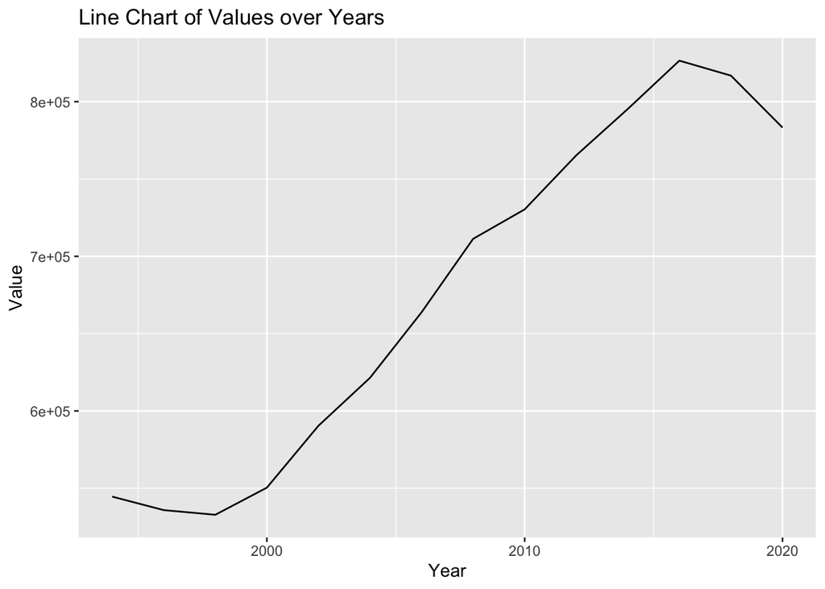

```r
years <- c(1994, seq(1996, 2020, by = 2))
values <- c(female_per_year)
df <- data.frame(years, values)

ggplot(df, aes(x = years, y = values)) +
  geom_line() +
  xlab("Year") +
  ylab("Value") +
  ggtitle("Line Chart of Values over Years")
```

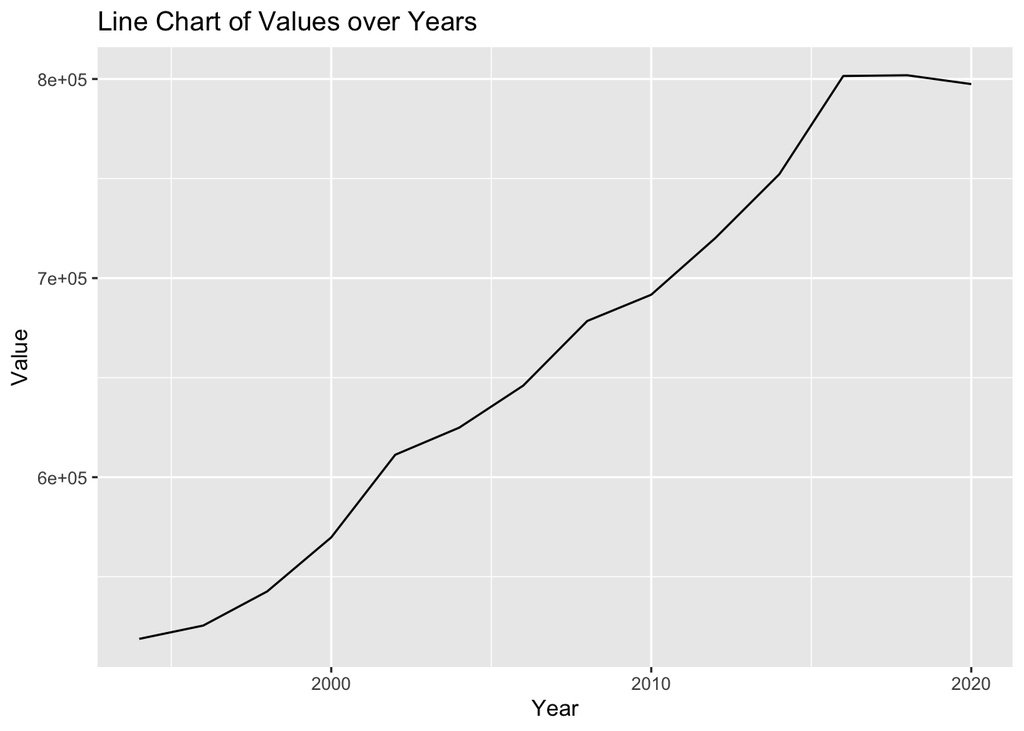

```r
years <- c(1994, seq(1996, 2020, by = 2))
values <- c(male_per_year)
df <- data.frame(years, values)

ggplot(df, aes(x = years, y = values)) +
  geom_line() +
  xlab("Year") +
  ylab("Value") +
  ggtitle("Line Chart of Values over Years")
```

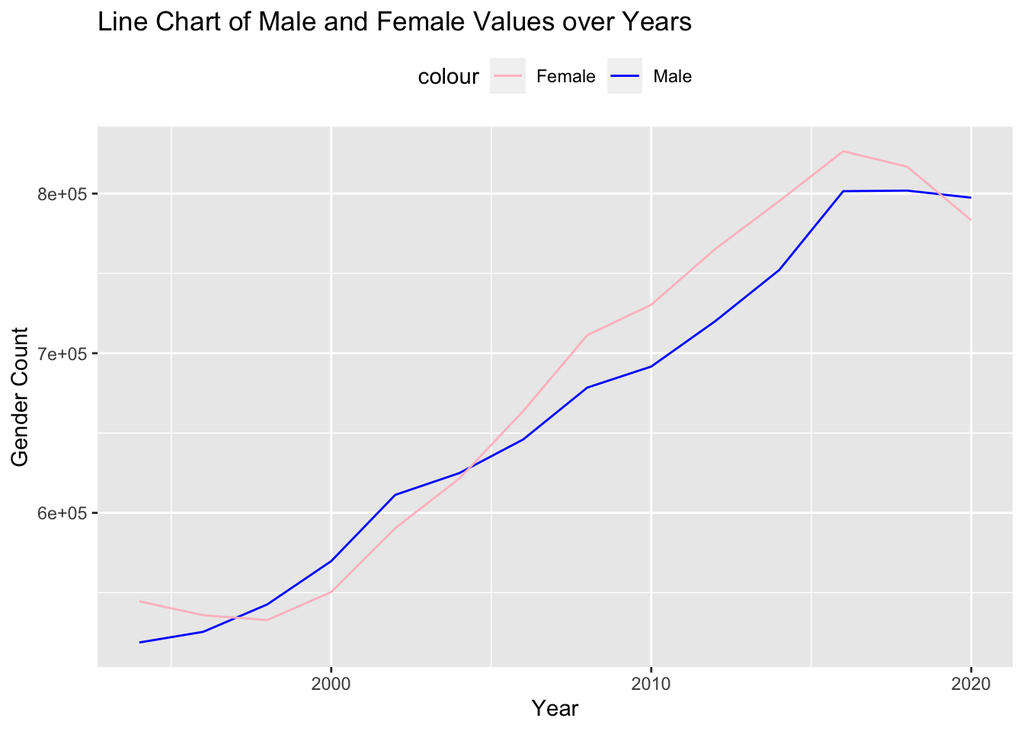

```r
years <- 1994:2020
years <- c(1994, seq(1996, 2020, by = 2))
male_values <- c(male_per_year)
female_values <- c(female_per_year)

df <- data.frame(years, male_values, female_values)

ggplot(df, aes(x = years)) +
  geom_line(aes(y = male_values, color = "Male")) +
  geom_line(aes(y = female_values, color = "Female")) +
  xlab("Year") +
  ylab("Gender Count") +
  ggtitle("Line Chart of Male and Female Values over Years") +
  scale_color_manual(values = c("Male" = "blue", "Female" = "pink")) +
  theme(legend.position = "top")
```

- Y[i,2,j,k,t]
- #i, no of records/institution
- #j/p Majors
- #k/q: Race
- #t/T Year

```r
T <- 14
year <- list()
for (t in 1:T){
  year[t] <- 1994 + 2*(t-1)
}
#year
```